[figure not shown]

### Cycle Counts - tracked across 66 counters in Scotland, with the first coming live in Jun 2017 …

[figure not shown]

# Overview

> Starting with the installation of 11 bicycle (and pedestrian) counters in a number of counties predominantly in west, central Scotland, from June 2017 and through to Aug 2020, when the 63rd counter was installed in Fort William in the Highlands, and a further three in Edinburgh in Jun and Jul 2021.

### Bicycle & Pedestrian Counts

[interactive chart not shown]

### Counter Locations

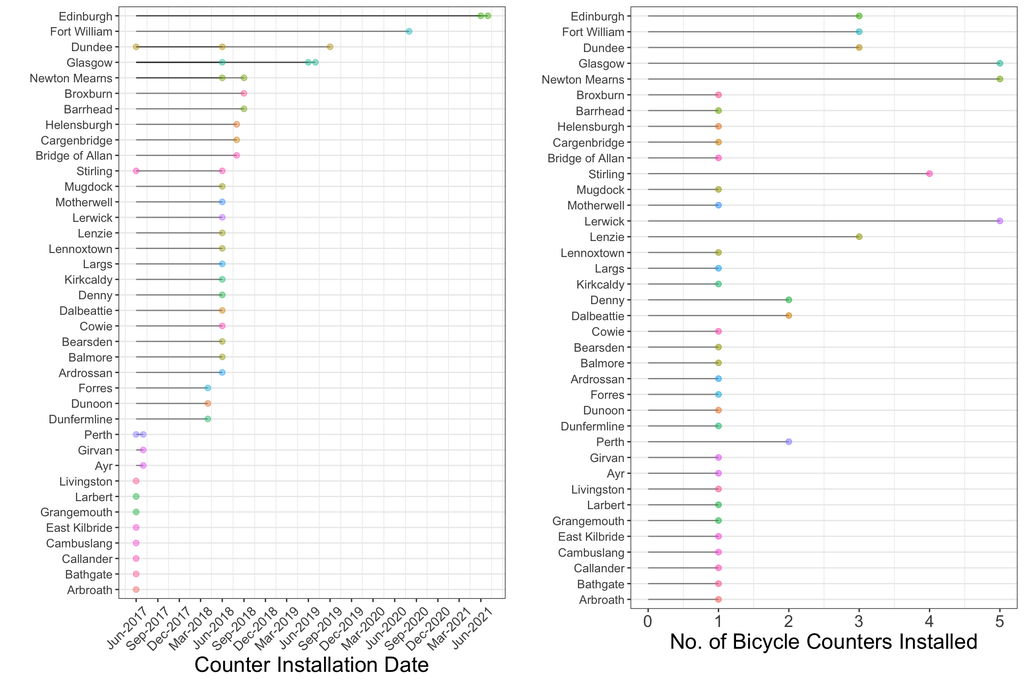

### Counter Data Summaries

Total count per year

| traffic mode | 2017 | 2018 | 2019 | 2020 | 2021 | total |
| --- | --- | --- | --- | --- | --- | --- |
| bicycle | 121,410 | 334,577 | 1,079,064 | 2,061,402 | 1,382,533 | 4,978,986 |
| pedestrian | 321,198 | 910,552 | 3,711,360 | 7,784,947 | 8,114,645 | 20,842,702 |

Average count by hour

| traffic mode | 2017 | 2018 | 2019 | 2020 | 2021 |
| --- | --- | --- | --- | --- | --- |
| bicycle | 10 | 6 | 13 | 24 | 23 |
| pedestrian | 28 | 17 | 45 | 90 | 147 |

Average count by day (across counters)

| traffic mode | 2017 | 2018 | 2019 | 2020 | 2021 |
| --- | --- | --- | --- | --- | --- |
| bicycle | 42 | 29 | 53 | 96 | 93 |
| pedestrian | 110 | 84 | 179 | 360 | 604 |

As at end Aug 2021 nearly **5m bikes** and just under **21m pedestrians** had been recorded going past all counters. Average count per day dropped in 2018 for both types of counters before starting to rise again. Looking at counts overall, **cycling peaked in May 2020**, two months after the first COVID-19 lockdown was imposed, then continued to drop after plateauing over the summer. Despite further restrictions **in 2021 cycling dropped overall**. Walking, overall, however continued to rise in 2021. But even this started to decrease in April, and by June had dropped below the same month in 2020. However, both cycling and walking started to rise again in Jul 2021, both over the 2020 figures, but then fell again in Aug.

# Cycling through the Week

### Cycling – Changes through the Week

[interactive chart not shown]

### Change over Time – Cycling through the Week

[interactive chart not shown]

# Cycling through the Year

> Comparing total count for each location against averages per hour through the day… this gets more interesting looking at the data month on month, as we can see how cycling changes through the full period for which counters were installed and working.

### Average Monthly Count

[interactive chart not shown]

### Monthly Totals

[interactive chart not shown]

# Variation across Locations

### By Year

[interactive chart not shown]

### By Month

[interactive chart not shown]

# As the Seasons Change

### Monthly Counts per Location

[interactive chart not shown]

### Changes in Counts by Year

[interactive chart not shown]

# Lerwick – Change through the Seasons

### Lerwick – Change through the Seasons

# Stirling, Bridge of Allan & the Cycle Scheme

### Stirling, Bridge of Allan & the Cycle Scheme

# About

> About …

Counter data may be accessed via Cycling Scotland's [Active Travel Open Data Portal](https://usmart.io/org/cyclingscotland). The data used in the analysis presented was accessed via the API at the level of detail for both pedestrian and cycle counters operated under Cycling Scotland's National Monitoring Framework. To use the API you must register and request an API key. Alternatively, a [dump may be downloaded](https://usmart.io/org/cyclingscotland/discovery/discovery-view-detail/7ffbe5d6-fa13-4352-829d-0bb0a58e3355) from the portal.  
[Historical weather pattern data](https://www.metoffice.gov.uk/research/climate/maps-and-data/uk-and-regional-series) was obtained from the Met Office.